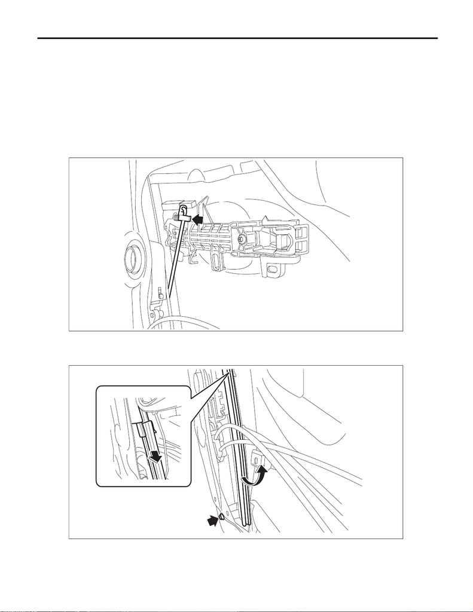

SL-37

Front Door Latch and Door Lock Actuator Assembly

SECURITY AND LOCKS

10.Front Door Latch and Door Lock Actuator Assembly

A: REMOVAL

1) Raise the glass assembly - front door to the top position.

2) Disconnect the ground cable from battery and wait for at least 60 seconds before starting work. <Ref. to

NT-5, BATTERY, NOTE, Note.>

NOTE:

For models other than STI model, disconnect the ground terminal from battery sensor.

3) Remove the trim panel - front door. <Ref. to EI-56, FRONT DOOR, REMOVAL, Door Trim.>

4) Remove the sealing cover - front door. <Ref. to EB-32, REMOVAL, Front Sealing Cover.>

5) Remove the rod clamp and remove the rod.

6) Remove the sash COMPL - lower.

(1) Remove the lower side of the running channel - front door.

(2) Remove the bolts, and remove the sash COMPL - lower.

SL-01449

SL-01450

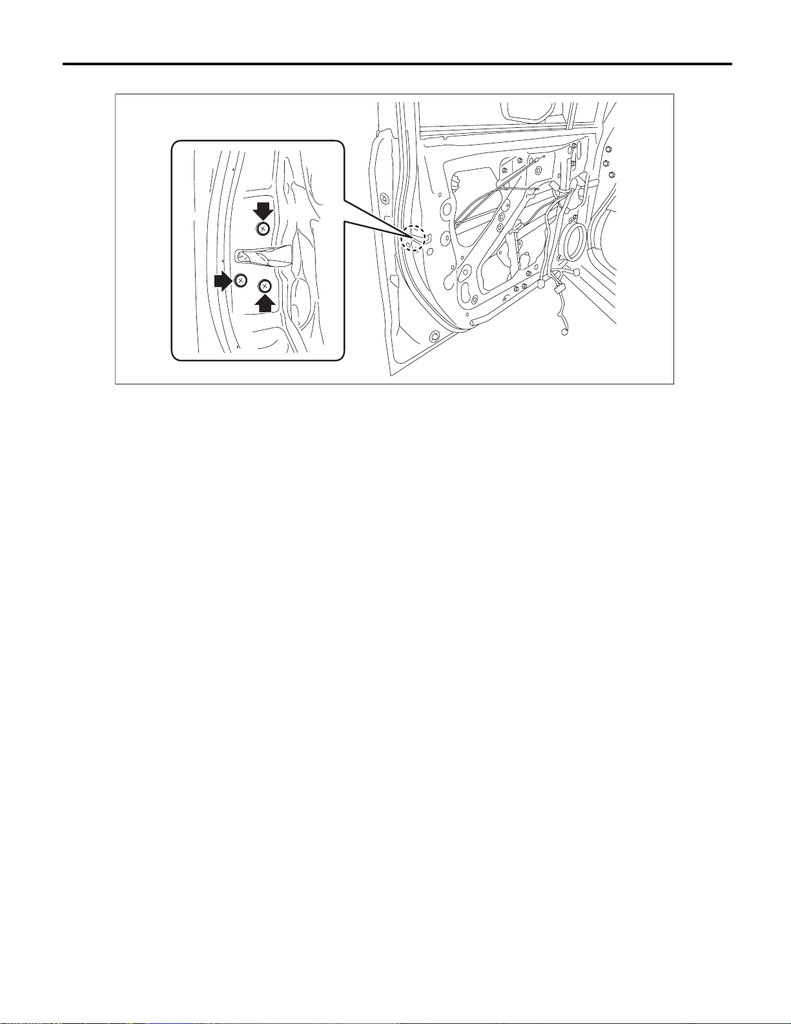

SL-38

Front Door Latch and Door Lock Actuator Assembly

SECURITY AND LOCKS

7) Remove the screws to remove the latch & actuator assembly - front.

B: INSTALLATION

1) Before installation, check the following items.

• Cable and rod are free from deformation.

• Grease is applied sufficiently to rod joints.

If grease is insufficient, add it as necessary before assembling the rod.

2) Install the latch and actuator assembly - front.

3) Install the rod clamp to the frame assembly - front door outer.

4) Install the sash COMPL - lower.

Tightening torque:

7.5 N·m (0.8 kgf-m, 5.5 ft-lb)

5) Install the sealing cover - front door.

6) Install the trim panel - front door.

7) Connect the battery ground terminal. <Ref. to NT-5, BATTERY, NOTE, Note.>

NOTE:

For models other than STI model, connect the ground terminal to battery sensor.

SL-01451

[figure not shown]

SL-39

Front Door Latch and Door Lock Actuator Assembly

SECURITY AND LOCKS

C: INSPECTION

1. LATCH

Check if the latch operates normally.

If the cable or rod is faulty, replace the latch & actuator assembly - front.

2. LOCK ACTUATOR

1) Check door lock operation

Check the door lock operation when battery voltage is applied between the connectors.

2) Check position switch

Measure the resistance between connector terminals.

Preparation tool:

Circuit tester

3) Replace the latch & actuator assembly - front if it is found defective.

SL-02880

1

10

342

Terminal No. Inspection conditions Standard

4 (+) — 1 (–)

Apply battery voltage.

LOCK

1 (+) — 4 (–) UNLOCK

Terminal No. Inspection conditions Standard

8 — 7

LOCK 1 MΩ or more

UNLOCK Less than 1 Ω